# Name

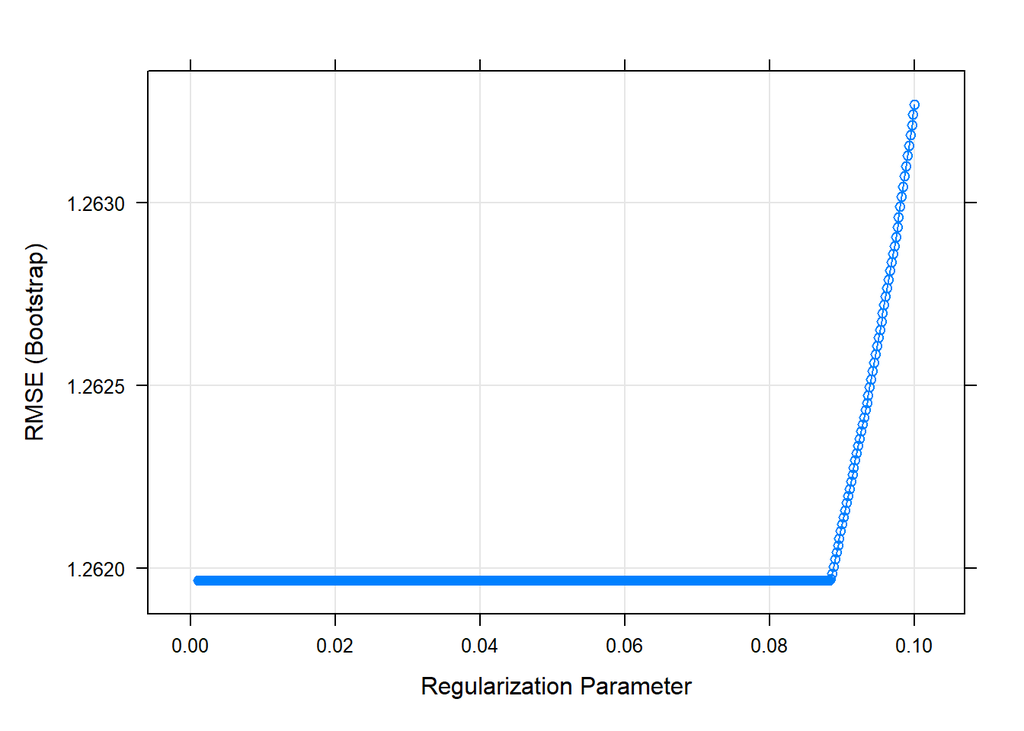

```r
plot(model4)
```

From th plots it can be clearly seen that the two procedures are not far away from each other

```r
#Question Five
#First
gam1<-gam(LC50~s(TPSA,df=6)+s(SAacc,df=6)+s(H050,df=6)+s(MLOGP,df=6)+s(RDCHI,df=6)+s(GATS1p,df=6)+s(nN, df=6)+s(C040,df=6) ,data = df)
summary(gam1)
```

```
##
## Call: gam(formula = LC50 ~ s(TPSA, df = 6) + s(SAacc, df = 6) + s(H050,
##     df = 6) + s(MLOGP, df = 6) + s(RDCHI, df = 6) + s(GATS1p,
##     df = 6) + s(nN, df = 6) + s(C040, df = 6), data = df)
## Deviance Residuals:
##      Min       1Q   Median       3Q      Max
## -3.97695 -0.76022 -0.05034  0.52376  5.24542
##
## (Dispersion Parameter for gaussian family taken to be 1.284)
##
##     Null Deviance: 1511.253 on 545 degrees of freedom
## Residual Deviance: 639.4123 on 498.0009 degrees of freedom
## AIC: 1733.709
##
## Number of Local Scoring Iterations: NA
##
## Anova for Parametric Effects
##                    Df Sum Sq Mean Sq  F value    Pr(>F)
## s(TPSA, df = 6)     1   0.00    0.00   0.0009 0.9765068
## s(SAacc, df = 6)    1  51.80   51.80  40.3447 4.805e-10 ***
## s(H050, df = 6)     1  56.57   56.57  44.0628 8.328e-11 ***
## s(MLOGP, df = 6)    1 427.11  427.11 332.6549 < 2.2e-16 ***
## s(RDCHI, df = 6)    1   2.12    2.12   1.6497 0.1995920
## s(GATS1p, df = 6)   1  16.62   16.62  12.9449 0.0003528 ***
## s(nN, df = 6)       1  30.80   30.80  23.9855 1.314e-06 ***
## s(C040, df = 6)     1   2.26    2.26   1.7637 0.1847663
## Residuals         498 639.41    1.28
## ---
## Signif. codes:  0 '***' 0.001 '**' 0.01 '*' 0.05 '.' 0.1 ' ' 1
##
## Anova for Nonparametric Effects
##                   Npar Df Npar F     Pr(F)
## (Intercept)
## s(TPSA, df = 6)         5 7.7965 4.452e-07 ***
## s(SAacc, df = 6)        5 7.7938 4.476e-07 ***
## s(H050, df = 6)         5 1.3250 0.2520532
## s(MLOGP, df = 6)        5 4.5370 0.0004694 ***
## s(RDCHI, df = 6)        5 6.5317 6.729e-06 ***
## s(GATS1p, df = 6)       5 1.1681 0.3237162
## s(nN, df = 6)           5 4.5816 0.0004273 ***
## s(C040, df = 6)         4 5.8730 0.0001266 ***
## ---
## Signif. codes:  0 '***' 0.001 '**' 0.01 '*' 0.05 '.' 0.1 ' ' 1
```

```r
#Second
gam2<-gam(LC50~s(TPSA,df=12)+s(SAacc,df=12)+s(H050,df=12)+s(MLOGP,df=12)+s(RDCHI,df=12)+s(GATS1p,df=12)+s(nN, df=12)+s(C040,df=12) ,data = df)
summary(gam2)
```

```
##
## Call: gam(formula = LC50 ~ s(TPSA, df = 12) + s(SAacc, df = 12) + s(H050,
##     df = 12) + s(MLOGP, df = 12) + s(RDCHI, df = 12) + s(GATS1p,
##     df = 12) + s(nN, df = 12) + s(C040, df = 12), data = df)
## Deviance Residuals:
##      Min       1Q   Median       3Q      Max
## -3.64621 -0.64791 -0.03482  0.52582  5.15551
##
## (Dispersion Parameter for gaussian family taken to be 1.2119)
##
##     Null Deviance: 1511.253 on 545 degrees of freedom
## Residual Deviance: 559.9179 on 461.9981 degrees of freedom
## AIC: 1733.228
##
## Number of Local Scoring Iterations: NA
##
## Anova for Parametric Effects
##                     Df Sum Sq Mean Sq  F value    Pr(>F)
## s(TPSA, df = 12)     1   0.23    0.23   0.1880  0.664818
## s(SAacc, df = 12)    1 234.78  234.78 193.7207 < 2.2e-16 ***
## s(H050, df = 12)     1 110.24  110.24  90.9642 < 2.2e-16 ***
## s(MLOGP, df = 12)    1 384.74  384.74 317.4570 < 2.2e-16 ***
## s(RDCHI, df = 12)    1   0.56    0.56   0.4610  0.497500
## s(GATS1p, df = 12)   1  11.72   11.72   9.6678  0.001991 **
## s(nN, df = 12)       1  24.97   24.97  20.6040 7.212e-06 ***
## s(C040, df = 12)     1   2.72    2.72   2.2412  0.135063
## Residuals          462 559.92    1.21
## ---
## Signif. codes:  0 '***' 0.001 '**' 0.01 '*' 0.05 '.' 0.1 ' ' 1
##
## Anova for Nonparametric Effects
##                    Npar Df  Npar F     Pr(F)
## (Intercept)
## s(TPSA, df = 12)        11 12.3338 < 2.2e-16 ***
## s(SAacc, df = 12)       11  5.8616 6.204e-09 ***
## s(H050, df = 12)         9  9.2146 6.832e-13 ***
## s(MLOGP, df = 12)       11  5.3520 5.198e-08 ***
## s(RDCHI, df = 12)       11  4.9391 2.890e-07 ***
## s(GATS1p, df = 12)      11  0.9480    0.4938
## s(nN, df = 12)           7  4.8240 2.927e-05 ***
## s(C040, df = 12)         4  0.5584    0.6930
## ---
## Signif. codes:  0 '***' 0.001 '**' 0.01 '*' 0.05 '.' 0.1 ' ' 1
```

By changing the levels of complexity the significance of the regression coefficients change but there are some that do not chage their significance.

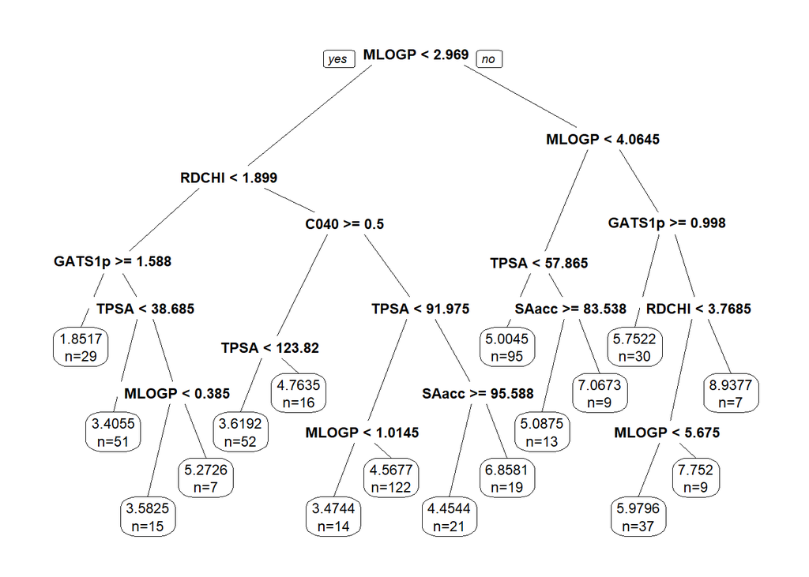

```r
#Question 6
#build the initial tree
tree <- rpart(LC50 ~ ., data=df, control=rpart.control(cp=.0001))
#identify best cp value to use
best <- tree$cptable[which.min(tree$cptable[,"xerror"]),"CP"]
#produce a pruned tree based on the best cp value
pruned_tree <- prune(tree, cp=best)
#plot the pruned tree
prp(pruned_tree,
    faclen=0, #use full names for factor labels
    extra=1, #display number of obs. for each terminal node
    roundint=F, #don't round to integers in output
    digits=5) #display 5 decimal places in output
```

Pruning reduces the size of decision trees by removing parts of the tree that do not provide power to classify instances. Decision trees are the most susceptible out of all the machine learning algorithms to overfitting and effective pruning can reduce this likelihood.

#Problem 2

```r
data(PimaIndiansDiabetes)
head(PimaIndiansDiabetes)
```

|  | pregnant | glucose | pressure | triceps | insulin | mass | pedigree | age | diabetes |
| --- | --- | --- | --- | --- | --- | --- | --- | --- | --- |
| 1 | 6 | 148 | 72 | 35 | 0 | 33.6 | 0.627 | 50 | pos |
| 2 | 1 | 85 | 66 | 29 | 0 | 26.6 | 0.351 | 31 | neg |
| 3 | 8 | 183 | 64 | 0 | 0 | 23.3 | 0.672 | 32 | pos |
| 4 | 1 | 89 | 66 | 23 | 94 | 28.1 | 0.167 | 21 | neg |
| 5 | 0 | 137 | 40 | 35 | 168 | 43.1 | 2.288 | 33 | pos |
| 6 | 5 | 116 | 74 | 0 | 0 | 25.6 | 0.201 | 30 | neg |

```r
#Divide the dataset
#make this example reproducible
set.seed(1)

#use 2/3 of dataset as training set and 1/3 as test set
sample <- sample(c(TRUE, FALSE), nrow(PimaIndiansDiabetes), replace=TRUE, prob=c(2/3,1/3))

train  <- PimaIndiansDiabetes[sample, ]
test   <- PimaIndiansDiabetes[!sample, ]
```

```r
#Question 1
# 5-fold procedure
trControl <- trainControl(method  = "cv",
                          number  = 5)

fit <- train(diabetes ~ .,
             method     = "knn",
             tuneGrid   = expand.grid(k = 1:10),
             trControl  = trControl,
             metric     = "Accuracy",
             data       = PimaIndiansDiabetes)
fit$results
```

|  | k | Accuracy | Kappa | AccuracySD | KappaSD |
| --- | --- | --- | --- | --- | --- |
| 1 | 1 | 0.6667091 | 0.2698246 | 0.03786725 | 0.08766119 |
| 2 | 2 | 0.6693150 | 0.2647028 | 0.01637298 | 0.02930209 |
| 3 | 3 | 0.6849079 | 0.2951884 | 0.02723442 | 0.04095720 |
| 4 | 4 | 0.6822596 | 0.2782015 | 0.03526408 | 0.06026688 |
| 5 | 5 | 0.7057296 | 0.3265665 | 0.02923668 | 0.04870609 |
| 6 | 6 | 0.7226806 | 0.3653387 | 0.04478012 | 0.08811295 |
| 7 | 7 | 0.7096172 | 0.3316694 | 0.04244537 | 0.08237451 |
| 8 | 8 | 0.7239708 | 0.3683130 | 0.02836376 | 0.06772070 |
| 9 | 9 | 0.7213394 | 0.3637858 | 0.05192289 | 0.10967521 |
| 10 | 10 | 0.7213904 | 0.3689589 | 0.03381230 | 0.06689403 |

```r
#loo cross-validation procedure
train.control <- trainControl(method  = "LOOCV", number = 5)

fit <- train(diabetes~ .,
             method     = "knn",
             tuneGrid   = expand.grid(k = 1:10),
             trControl  = train.control,
             metric     = "Accuracy",
             data       = PimaIndiansDiabetes)
fit$results
```

|  | k | Accuracy | Kappa |
| --- | --- | --- | --- |
| 1 | 1 | 0.6796875 | 0.2938221 |
| 2 | 2 | 0.6718750 | 0.2828175 |
| 3 | 3 | 0.6940104 | 0.3189023 |
| 4 | 4 | 0.7005208 | 0.3316382 |
| 5 | 5 | 0.7148438 | 0.3516514 |
| 6 | 6 | 0.7239583 | 0.3695558 |
| 7 | 7 | 0.7278646 | 0.3812564 |
| 8 | 8 | 0.7200521 | 0.3634934 |
| 9 | 9 | 0.7343750 | 0.3911584 |
| 10 | 10 | 0.7304688 | 0.3871774 |

K-NN performs much better if all of the data have the same scale

```r
#Question 2
PimaIndiansDiabetes$diabetes <- ifelse(PimaIndiansDiabetes$diabetes == 'pos',1,0)
gam3 <- gam(diabetes~s(pregnant)+s(glucose)+s(pressure)+s(triceps)+s(insulin)+s(mass)+s(pedigree)+s(age), data=PimaIndiansDiabetes)

#Best Model
model.forward<- step(gam3, ,direction = "forward")
```

```
## Start:  AIC=751.64
## diabetes ~ s(pregnant) + s(glucose) + s(pressure) + s(triceps) +
##     s(insulin) + s(mass) + s(pedigree) + s(age)
```

```r
#Question 3
#Classification Tree
fit <- rpart(diabetes~., data =train,method = 'class')
predictions <- predict(fit,train)
# Model performance
# Training error
RMSE(predictions, test$diabetes)
```

```
## [1] NA
```

```r
#Random Forest
rf <- randomForest(diabetes~., data=train, proximity=TRUE)
predictions <- predict(rf,test)
# Model performance
# Training error
RMSE(predictions, test$diabetes)
```

```
## [1] NA
```

```r
#AdaBoost
# train a model using our training data
train$diabetes <- as.factor(train$diabetes)
model_adaboost <- boosting(diabetes~., data=train, boos=TRUE, mfinal = 50)
#use model to make predictions on test data
pred_test <- predict(model_adaboost, test)

# Training error
pred_test$error
```

```
## [1] 0.2749004
```

```r
#Question 5
data(PimaIndiansDiabetes2)
#use 2/3 of dataset as training set and 1/3 as test set
sample <- sample(c(TRUE, FALSE), nrow(PimaIndiansDiabetes2), replace=TRUE, prob=c(2/3,1/3))

train  <- PimaIndiansDiabetes2[sample, ]
test  <- PimaIndiansDiabetes2[!sample, ]
head(PimaIndiansDiabetes2)
```

|  | pregnant | glucose | pressure | triceps | insulin | mass | pedigree | age | diabetes |
| --- | --- | --- | --- | --- | --- | --- | --- | --- | --- |
| 1 | 6 | 148 | 72 | 35 | NA | 33.6 | 0.627 | 50 | pos |
| 2 | 1 | 85 | 66 | 29 | NA | 26.6 | 0.351 | 31 | neg |
| 3 | 8 | 183 | 64 | NA | NA | 23.3 | 0.672 | 32 | pos |
| 4 | 1 | 89 | 66 | 23 | 94 | 28.1 | 0.167 | 21 | neg |
| 5 | 0 | 137 | 40 | 35 | 168 | 43.1 | 2.288 | 33 | pos |
| 6 | 5 | 116 | 74 | NA | NA | 25.6 | 0.201 | 30 | neg |

```r
#Second
PimaIndiansDiabetes2$diabetes <- ifelse(PimaIndiansDiabetes2$diabetes == 'pos',1,0)
gam4 <- gam(diabetes~s(pregnant)+s(glucose)+s(pressure)+s(triceps)+s(insulin)+s(mass)+s(pedigree)+s(age), data=PimaIndiansDiabetes2)

#Best Model
model.forward<- step(gam4, ,direction = "forward")
```

```
## Start:  AIC=381.32
## diabetes ~ s(pregnant) + s(glucose) + s(pressure) + s(triceps) +
##     s(insulin) + s(mass) + s(pedigree) + s(age)
```

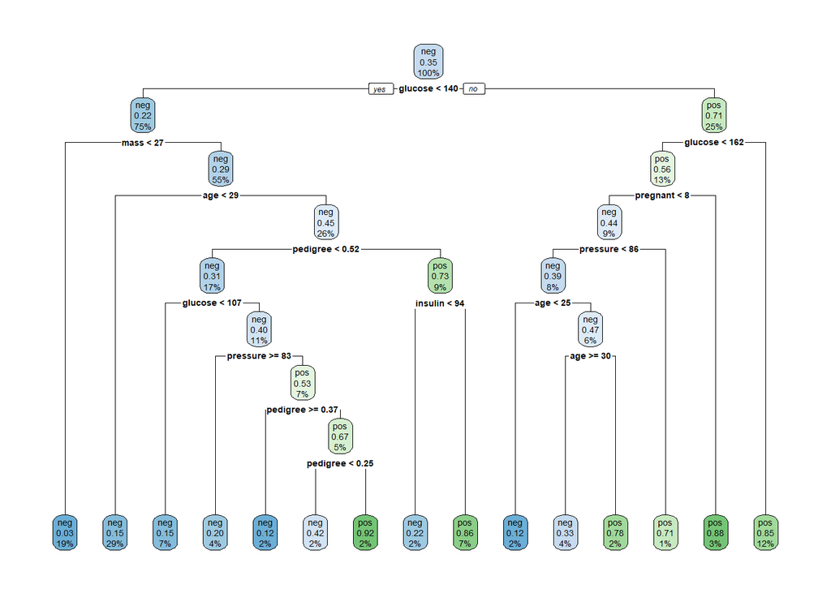

```r
#Third
#Classification Tree
fit <- rpart(diabetes~., data =train,method = 'class')
rpart.plot(fit,extra=106)
```

Different results are obtained as many machine learning algorithms fail if the dataset contains missing values this can lead to building a biased machine learning model which will lead to incorrect results if the missing values are not handled properly.